# Using Spotify song attributes to determine whether or not I like a song

Wilber Delgado

# Introduction

Like many people, I have always been interested in finding new music, but I have found that I am a very picky music listener. This sometimes makes it quite difficult for people and music apps to “put me on” new music. I feel like a lot of the music I like tends to depend on the vibe of the song as I generally like songs with a chiller vibe, however I do find interest in music like Techno or songs that somewhat combine EDM and Rock. Although music apps have their own models that suggest songs, I hardly find myself getting new music from apps’ recommendations.

After looking around kaggle for a while I found a data set that had songs pulled from a spotify playslist and their attributes and it reminded me of how much I enjoy music and gave me the idea to try and make a machine learning model that could identify whether or not I like a song based on its attributes. This was also what the original poster of the Kaggle data set had done, which was make a machine learning model that could identify songs that he liked or disliked based the attributes of the songs from a playlist they had made.

# Tidying data

## Collecting/Setting up data

Originally I planned to use the data set that I had found on kaggle as many of the songs I had first seen were familiar, however when I looked at the full data set I noticed that a majority of the songs I had never seen or heard which would have resulted in a lot of songs being numbered “0” as in i do not like them. To not have this negatively affect my project I decided it would be better if I created a playlist myself and added songs that I likes and did not like. Using the spotify API was not the easiest thing to do as I am not advanced in python. However after much trial and error I was able to use Google colab to read the playlist I made for this project and retrieve the songs’ attributes into a csv file. The only issue I had was that since my playlist was 1000 songs the program would get an error after running reading and retrieving some of the songs attributes. For this reason I made it to where it would read 100 songs at a time and I ended up with 10 csv files.

I then combined all the csv files into 1. I had to exclude “df6.csv” as there was a song in that range that did not have attributes so it was causing errors. To fix this I went back and added more songs to my playlist and retrieved 100 more songs so I can have a final total of 1000 songs in my data set.

```r
library(dplyr)
library(workflows)
library(tibble)
library(ggplot2)
library(corrplot)
library(readr)
library(tidymodels)
library(xgboost)
library(kknn)
library(glmnet)
library(parsnip)
library(kernlab)
library(recipes)
library(rsample)

setwd("/Users/wilberdelgado/Downloads/drive-download-20240314T043832Z-001")

csv_files <- list.files(pattern = "\\.csv$")
csv_files <- csv_files[csv_files != "df6.csv"]

list_of_dfs <- lapply(csv_files, read.csv)

combined_df <- bind_rows(list_of_dfs)
```

After combining the csv files I dropped columns that I did not require such as id, uri, analysis_url, etc. I also added a column names “opinion” which would hold my opinion about a song where “1” means that I like the song and “0” means I dislike the song. After adding the “opinion” column, I exported my combined data set, and manually marked the songs I like with the number 1. After this, rather than entering all the 0s manually I decided that I would just have R replace any “NA” under the “opinion” column to be a 0.

```r
combined_df <- select(combined_df, -c(X, type, id, uri, track_href, analysis_url))

# Add a blank column named "opinion"
combined_df$opinion <- NA

output_file_path <- "/Users/wilberdelgado/Downloads/combined_songs.csv"

# commented for rerun purposes
# write.csv(combined_df, output_file_path, row.names = TRUE)
```

```r
songs <- read.csv("/Users/wilberdelgado/Downloads/project_songs.csv")

songs <- songs[ , !(names(songs) %in% c("X"))]

songs$opinion[is.na(songs$opinion)] <- 0


head(songs)
```

```
##   danceability energy key loudness mode speechiness acousticness
## 1        0.795  0.797  10   -5.960    0      0.0634     0.004380
## 2        0.596  0.963   7   -6.032    1      0.0806     0.000443
## 3        0.770  0.622  11  -10.621    1      0.0260     0.328000
## 4        0.747  0.629   9   -8.509    0      0.0363     0.328000
## 5        0.776  0.701   9   -5.223    1      0.0254     0.513000
## 6        0.787  0.858   5   -4.969    0      0.0555     0.263000
##   instrumentalness liveness valence   tempo duration_ms time_signature
## 1          0.30200   0.1290   0.627 124.952      189614              4
## 2          0.87200   0.2850   0.148 137.004      244299              4
## 3          0.00603   0.1490   0.792 115.952      231247              3
## 4          0.00409   0.1540   0.793 127.819      163552              3
## 5          0.00000   0.0902   0.603 112.032      265045              3
## 6          0.00000   0.1030   0.964 125.093      157252              3
##     song_title         artist opinion
## 1   Rave Grave Walker & Royce       1
## 2 Fall In Love   Lilly Palmer       1
## 3      LAGUNAS     Peso Pluma       1
## 4         LUNA     Peso Pluma       1
## 5      BIPOLAR     Peso Pluma       1
## 6          TQM  Fuerza Regida       1
```

```r
set.seed(123) #Set seed for reproductibility

str(songs)
```

```
## 'data.frame':    1000 obs. of  16 variables:
##  $ danceability    : num  0.795 0.596 0.77 0.747 0.776 0.787 0.628 0.558 0.807 0.646 ...
##  $ energy          : num  0.797 0.963 0.622 0.629 0.701 0.858 0.668 0.648 0.595 0.736 ...
##  $ key             : int  10 7 11 9 9 5 8 9 0 5 ...
##  $ loudness        : num  -5.96 -6.03 -10.62 -8.51 -5.22 ...
##  $ mode            : int  0 1 1 0 1 0 1 0 1 0 ...
##  $ speechiness     : num  0.0634 0.0806 0.026 0.0363 0.0254 0.0555 0.117 0.055 0.0325 0.0449 ...
##  $ acousticness    : num  0.00438 0.000443 0.328 0.328 0.513 0.263 0.329 0.226 0.31 0.216 ...
##  $ instrumentalness: num  3.02e-01 8.72e-01 6.03e-03 4.09e-03 0.00 0.00 0.00 7.76e-06 2.44e-05 0.00 ...
##  $ liveness        : num  0.129 0.285 0.149 0.154 0.0902 0.103 0.139 0.0986 0.0735 0.415 ...
##  $ valence         : num  0.627 0.148 0.792 0.793 0.603 0.964 0.845 0.844 0.392 0.873 ...
##  $ tempo           : num  125 137 116 128 112 ...
##  $ duration_ms     : int  189614 244299 231247 163552 265045 157252 136913 187226 239845 212878 ...
##  $ time_signature  : int  4 4 3 3 3 3 3 3 4 3 ...
##  $ song_title      : chr  "Rave Grave" "Fall In Love" "LAGUNAS" "LUNA" ...
##  $ artist          : chr  "Walker & Royce" "Lilly Palmer" "Peso Pluma" "Peso Pluma" ...
##  $ opinion         : num  1 1 1 1 1 1 1 1 1 1 ...
```

After looking at the variables in my data set, key, mode, and time_signature are integers int and likely represent categorical data since they denote specific categories. I decided to conver them to factors for more meaningful analysis. Also my opinion column it meant to be a binary outcome so I decided to also convert it into a factor to clearly denote it as a categorical outcome for classification tasks

```r
songs$key <- as.factor(songs$key)
songs$mode <- as.factor(songs$mode)
songs$time_signature <- as.factor(songs$time_signature)

songs$opinion <- as.factor(songs$opinion)
```

```r
summary(songs)
```

```
##   danceability        energy            key         loudness       mode
##  Min.   :0.0000   Min.   :0.0105   1      :134   Min.   :-31.610   0:392
##  1st Qu.:0.4890   1st Qu.:0.4980   0      :108   1st Qu.: -9.099   1:608
##  Median :0.5900   Median :0.6265   9      : 94   Median : -6.967
##  Mean   :0.5924   Mean   :0.6140   2      : 91   Mean   : -7.514
##  3rd Qu.:0.7030   3rd Qu.:0.7542   5      : 90   3rd Qu.: -5.476
##  Max.   :0.9590   Max.   :0.9980   8      : 86   Max.   :  2.574
##                                    (Other):397
##   speechiness       acousticness       instrumentalness       liveness
##  Min.   :0.00000   Min.   :0.0000047   Min.   :0.0000000   Min.   :0.0303
##  1st Qu.:0.03658   1st Qu.:0.0407000   1st Qu.:0.0000000   1st Qu.:0.1040
##  Median :0.05885   Median :0.1740000   Median :0.0000298   Median :0.1360
##  Mean   :0.12687   Mean   :0.2833626   Mean   :0.0777054   Mean   :0.2052
##  3rd Qu.:0.19350   3rd Qu.:0.4647500   3rd Qu.:0.0058500   3rd Qu.:0.2642
##  Max.   :0.88300   Max.   :0.9830000   Max.   :0.9840000   Max.   :0.8900
##
##     valence           tempo        duration_ms     time_signature
##  Min.   :0.0000   Min.   :  0.0   Min.   : 12826   0:  2
##  1st Qu.:0.2730   1st Qu.: 92.0   1st Qu.:176697   1:  9
##  Median :0.4375   Median :119.9   Median :214641   3: 91
##  Mean   :0.4545   Mean   :120.0   Mean   :222463   4:882
##  3rd Qu.:0.6135   3rd Qu.:143.9   3rd Qu.:254252   5: 16
##  Max.   :0.9800   Max.   :215.7   Max.   :779560
##
##   song_title           artist          opinion
##  Length:1000        Length:1000        0:573
##  Class :character   Class :character   1:427
##  Mode  :character   Mode  :character
##
##
##
##
```

```r
summary(songs$tempo[songs$tempo == 0])
```

```
##    Min. 1st Qu.  Median    Mean 3rd Qu.    Max.
##       0       0       0       0       0       0
```

```r
songs[songs$tempo == 0, ]
```

```
##     danceability energy key loudness mode speechiness acousticness
## 88             0 0.4780  11  -16.569    0           0        0.927
## 877            0 0.0105   1  -31.610    1           0        0.933
##     instrumentalness liveness valence tempo duration_ms time_signature
## 88             0.000    0.335       0     0       14627              0
## 877            0.962    0.166       0     0       12826              0
##                                       song_title             artist opinion
## 88  EXACTLY WHAT YOU RUN FROM YOU END UP CHASING Tyler, The Creator       1
## 877                                        Intro      The Red Pears       0
```

```r
# Removing songs with 0 tempo
songs <- songs[songs$tempo != 0, ]
```

## Missing data

Fortunately none of my columns had any missing data.

```r
colSums(is.na(songs))
```

```
##     danceability           energy              key         loudness
##                0                0                0                0
##             mode      speechiness     acousticness instrumentalness
##                0                0                0                0
##         liveness          valence            tempo      duration_ms
##                0                0                0                0
##   time_signature       song_title           artist          opinion
##                0                0                0                0
```

# EDA

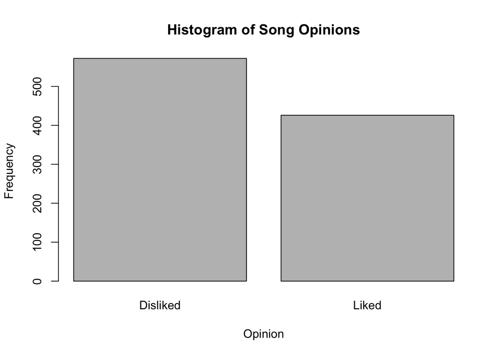

```r
opinion_counts <- table(songs$opinion)

# Create the bar plot
barplot(opinion_counts, main = "Histogram of Song Opinions", xlab = "Opinion", ylab = "Frequency", names.arg = c("Disliked", "Liked"))
```

I found that my data set was imbalanced with having more disliked songs than likes so I decided to even them out. the even split turned out to be 426 liked songs and 426 disliked songs.

```r
liked_songs <- filter(songs, opinion == 1)
not_liked_songs <- filter(songs, opinion == 0)

# Undersample the not liked songs to match the number of liked songs
not_liked_songs_undersampled <- sample_n(not_liked_songs, size = nrow(liked_songs))

# Combine back to get the balanced dataset
songs <- bind_rows(liked_songs, not_liked_songs_undersampled)
```

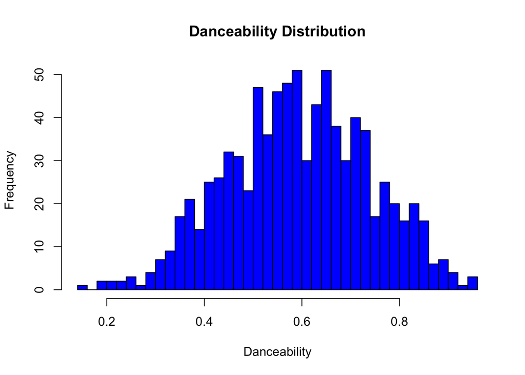

```r
# Plot a histogram to visualize the distribution of 'danceability'
hist(songs$danceability, main="Danceability Distribution", xlab="Danceability", col="blue", breaks=30)
```

The danceability distribution shows a relatively normal distribution which can work quite well for my machine learning models.

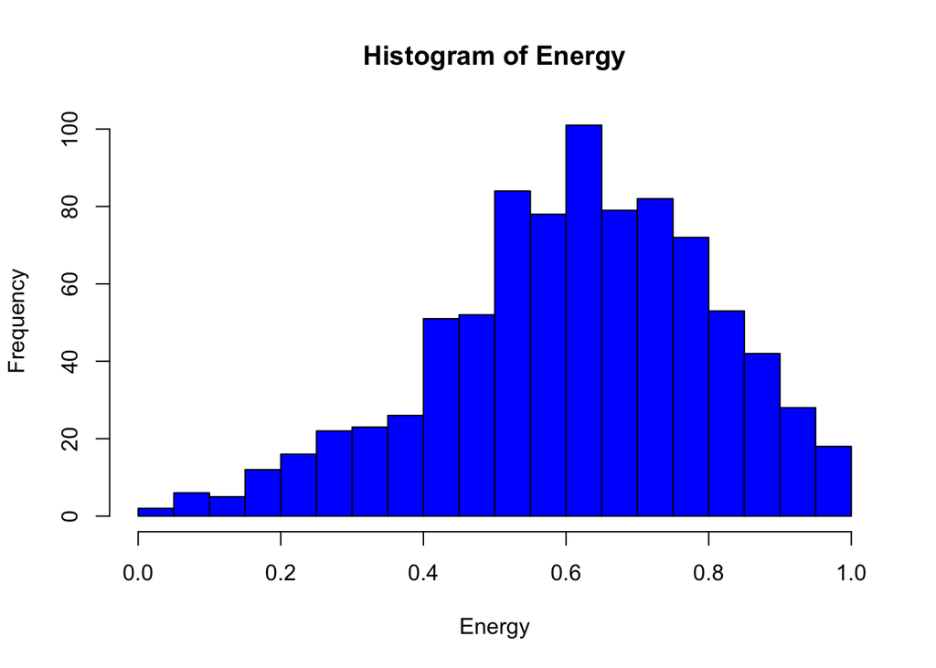

```r
hist(songs$energy, main="Histogram of Energy", xlab="Energy", col="blue", breaks=30)
```

Given the distribution, the energy variable does not appear to have any concerning outliers or skewness that would require data transformation before modeling.

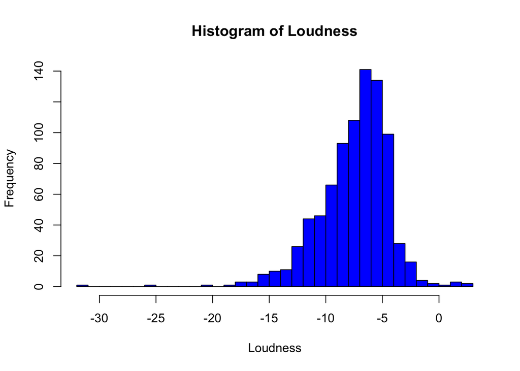

```r
hist(songs$loudness, main="Histogram of Loudness", xlab="Loudness", col="blue", breaks=30)
```

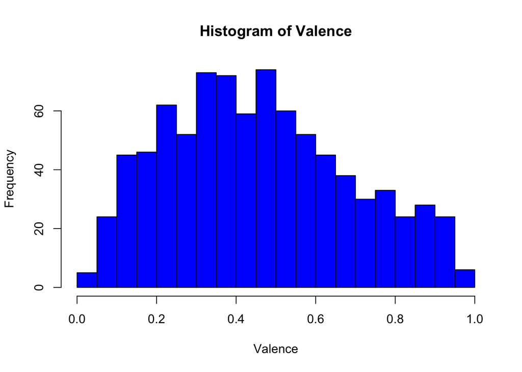

```r
hist(songs$valence, main="Histogram of Valence", xlab="Valence", col="blue", breaks=30)
```

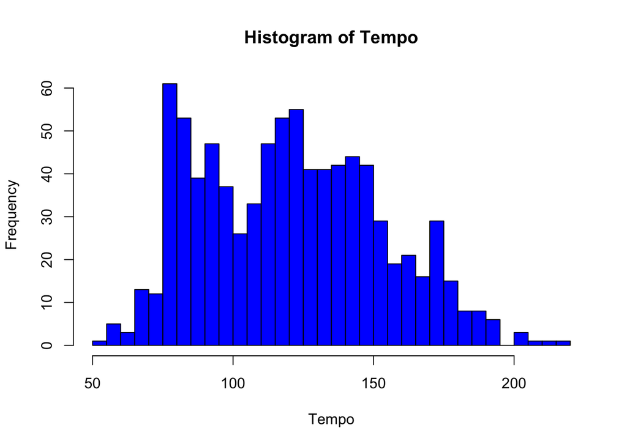

```r
hist(songs$tempo, main="Histogram of Tempo", xlab="Tempo", col="blue", breaks=30)
```

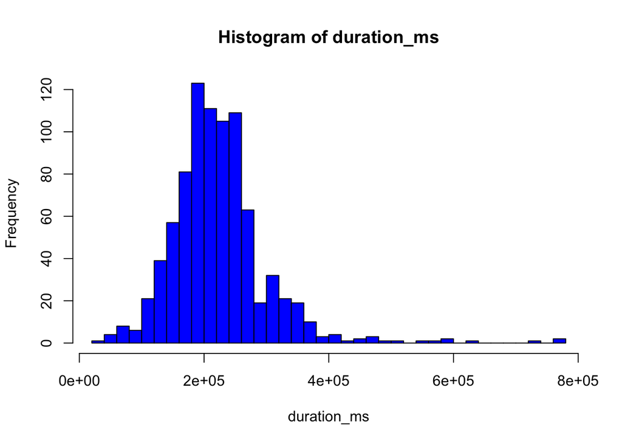

```r
hist(songs$duration_ms, main="Histogram of duration_ms", xlab="duration_ms", col="blue", breaks=30)
```

Next up I look at the factored variables.

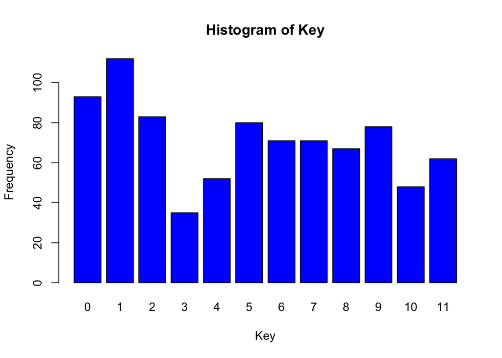

```r
key_counts <- table(songs$key)

# Create the bar plot
barplot(key_counts, main = "Histogram of Key", xlab = "Key", ylab = "Frequency", col="blue")
```

The histogram of key shows a wide spread value of keys. Key 1 seemed to be the most common from my playlist.

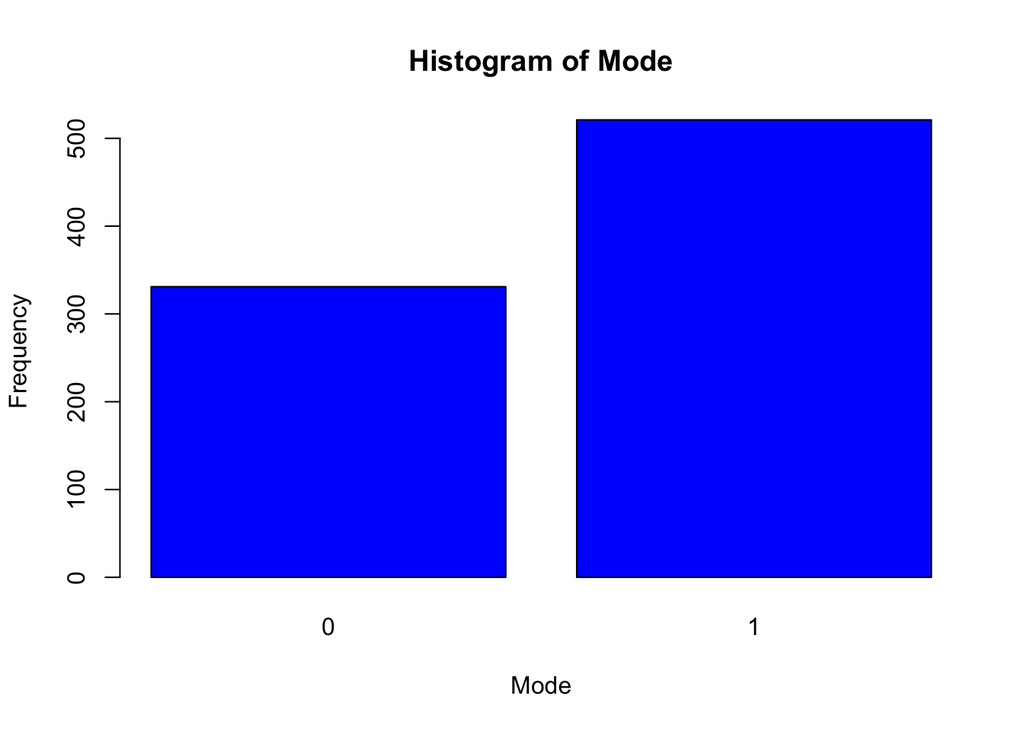

```r
mode_counts <- table(songs$mode)

# Create the bar plot
barplot(mode_counts, main = "Histogram of Mode", xlab = "Mode", ylab = "Frequency", col="blue")
```

The mode shows that that the modality of most of the tracks on my playlist are Major.

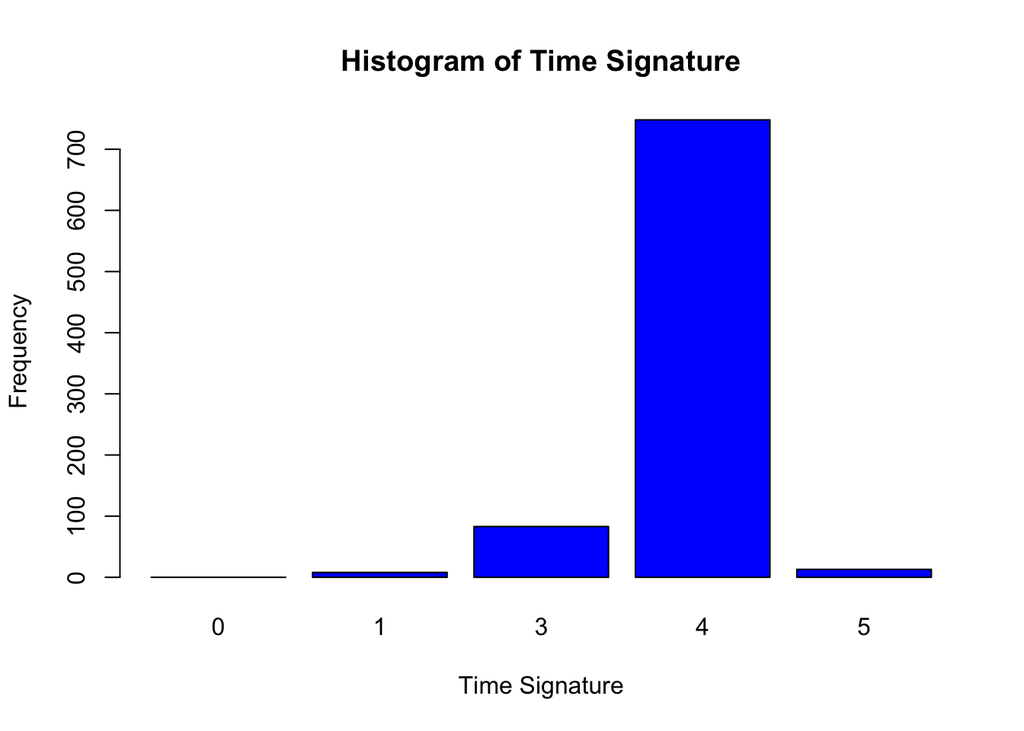

```r
timesignature_counts <- table(songs$time_signature)

# Create the bar plot
barplot(timesignature_counts, main = "Histogram of Time Signature", xlab = "Time Signature", ylab = "Frequency", col = "blue")
```

The time signature histogram indicates that a majority of my songs have 4 beats in each bar.

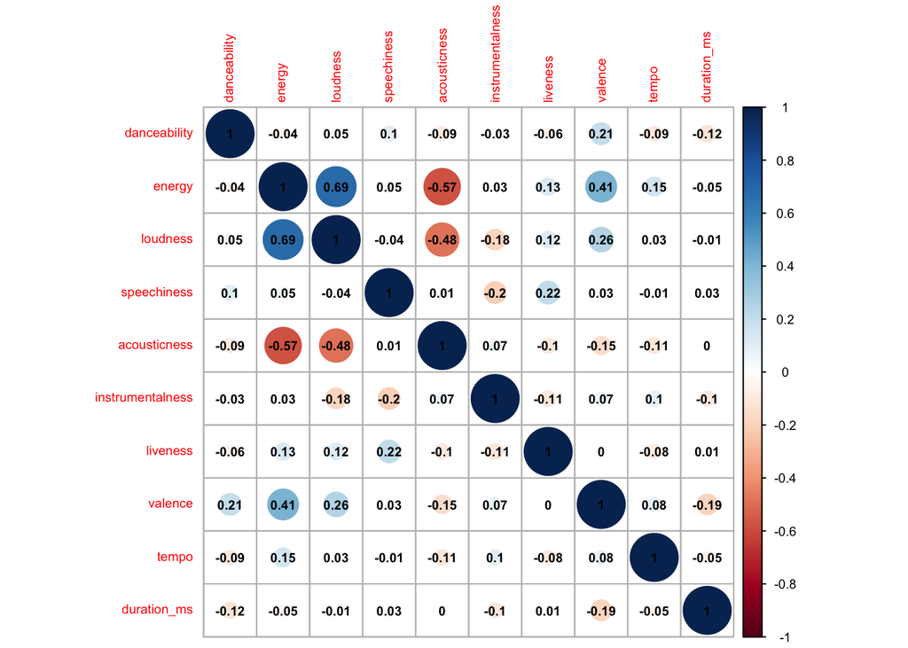

```r
# Find correlations between numeric predictors only
numeric_vars <- songs[sapply(songs, is.numeric)]
cor_matrix <- cor(numeric_vars, use="complete.obs")


corrplot(cor_matrix, method="circle", addCoef.col="black", number.cex = 0.6, tl.cex=0.6, cl.cex=0.6)
```

Based on the correlation plot, the highest correlated variables are loudness and energy. Other than that the correlation plot does not show any other variables that are too highly coordinated or too low coordinated.

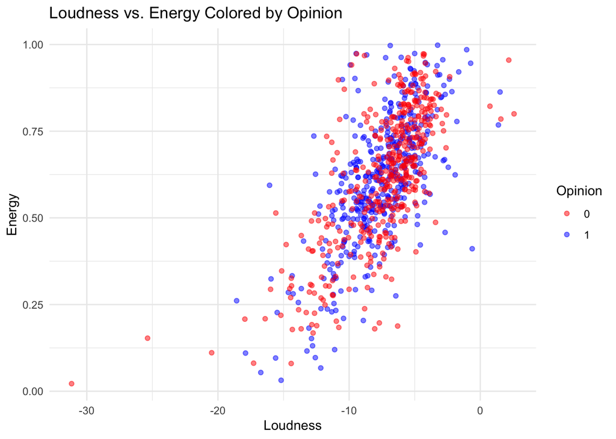

```r
ggplot(songs, aes(x=loudness, y=energy, color=factor(opinion))) +
  geom_point(alpha=0.5) +
  scale_color_manual(values=c('0'='red', '1'='blue')) +
  labs(title="Loudness vs. Energy Colored by Opinion",
       x="Loudness", y="Energy", color="Opinion") +
  theme_minimal()
```

After plotting the variables Energy and Loudness together, we can see that they are lots of points that overlap eachother, which might be a concern for model training, however it also makes sense that they correlate highly to one another because if a song is loud, it typically also has lots of energy in it. Overall their realtionship seems linear, and I do not think it will cause any issues with my models.

# Setting up for Models

## Splitting the data

First I go ahead and split the data with 70/30, with “opinion” stratified.

```r
# Splitting the dataset
split <- initial_split(songs, prop = .7, strata = opinion)

training_set <- training(split)
testing_set <- testing(split)
```

## Recipe

I then set up my recipe, which excludes song_titles and artists names as they are character variables that have no purpose in training a model.

```r
recipe <- recipe(opinion ~ ., data = training_set) %>%
  step_rm(song_title, artist) %>%
  step_zv(all_predictors()) %>%
  step_dummy(all_nominal(), -all_outcomes()) %>%
  step_normalize(all_numeric(), -all_outcomes())

# Prepare the recipe with the training data
prepared_recipe <- prep(recipe, training = training_set)

# Bake the recipe
baked_data <- bake(prepared_recipe, new_data = NULL)

colnames(baked_data)
```

```
##  [1] "danceability"      "energy"            "loudness"
##  [4] "speechiness"       "acousticness"      "instrumentalness"
##  [7] "liveness"          "valence"           "tempo"
## [10] "duration_ms"       "opinion"           "key_X1"
## [13] "key_X2"            "key_X3"            "key_X4"
## [16] "key_X5"            "key_X6"            "key_X7"
## [19] "key_X8"            "key_X9"            "key_X10"
## [22] "key_X11"           "mode_X1"           "time_signature_X1"
## [25] "time_signature_X3" "time_signature_X4" "time_signature_X5"
```

I then stratify my cross validation on opinion, my response variable.

```r
songs_fold <- vfold_cv(training_set, v = 10, strata = opinion)
```

# Model building

## Fit Models

The models I will be working with will be logistic regression, knn, random forest, boosted forest and support vector machine. For these models I set up the models with the parameters I would like to tune. I will set up the workflow with the models and recipe. I will then creating tuning grids for the parameters which will be tuned. The I will tune the model and specify the workflow and save the tuned models to an RDS file to save time and computer power on running the models

```r
# Define the logistic model specification
logistic_spec <- logistic_reg(penalty = tune(), mixture = tune()) %>%
  set_engine("glmnet") %>%
  set_mode("classification")


# Define the knn model specification
knn_spec <- nearest_neighbor(neighbors = tune()) %>%
  set_engine("kknn") %>%
  set_mode("classification")

# Define the random forest model specification
rf_spec <- rand_forest(
  trees = tune(),
  mtry = tune(),
  min_n = tune()
) %>%
  set_engine("ranger") %>%
  set_mode("classification")

# Define the bosted trees model specification
boosted_spec <- boost_tree(
    trees = tune(),
    min_n = tune(),
    learn_rate = tune()
  ) %>%
  set_engine("xgboost") %>%
  set_mode("classification")


# Define the support vector machine model specification
svm_spec <- svm_linear() %>%
  set_engine("kernlab") %>%
  set_mode("classification")
```

## Work flow

```r
# Create the workflows
logistic_wf <- workflow() %>%
  add_model(logistic_spec) %>%
  add_recipe(recipe)

knn_wf <- workflow() %>%
  add_model(knn_spec) %>%
  add_recipe(recipe)

rf_wf <- workflow() %>%
  add_model(rf_spec) %>%
  add_recipe(recipe)

boosted_wf <- workflow() %>%
  add_model(boosted_spec) %>%
  add_recipe(recipe)

svm_wf <- workflow() %>%
  add_model(svm_spec) %>%
  add_recipe(recipe)
```

## Grids

```r
# Define a tuning grids

knn_grid <- grid_regular(neighbors(range = c(1, 20)), levels = 5)

rf_grid <- grid_regular(
  mtry(range = c(1, 12)),
  trees(range = c(200,1000)),
  min_n(range = c(5,20)),
  levels = 8)


boosted_grid <- grid_regular(
    trees(range = c(50, 500)),
    min_n(range = c(5, 20)),
    learn_rate(range = c(0.01, 0.3)),
    levels = 5
)
```

## Results

```r
logistic_res <- tune_grid(
  logistic_wf,
  resamples = songs_fold)


knn_res <- tune_grid(
  knn_wf,
  resamples = songs_fold,
  grid = knn_grid
)

# commented out for rerun/knitting purposes
# rf_res <- tune_grid(
#  rf_wf,
#  resamples = songs_fold,
#  grid = rf_grid
#)


#boosted_res <- tune_grid(
# boosted_wf,
#  resamples = songs_fold,
#  grid = boosted_grid
#)

#svm_res <- fit_resamples(
#  svm_wf,
#  resamples = songs_fold
#)
```

```r
# write_rds(rf_res, file = "/Users/wilberdelgado/Downloads/rf.rds")
# write_rds(boosted_res, file = "/Users/wilberdelgado/Downloads/boosted.rds")
# write_rds(svm_res, file = "/Users/wilberdelgado/Downloads/svm.rds")
```

```r
rf_res <- read_rds(file = "/Users/wilberdelgado/Downloads/rf.rds")
boosted_res <- read_rds(file = "/Users/wilberdelgado/Downloads/boosted.rds")
svm_res <- read_rds(file = "/Users/wilberdelgado/Downloads/svm.rds")
```

# Model Autoplots

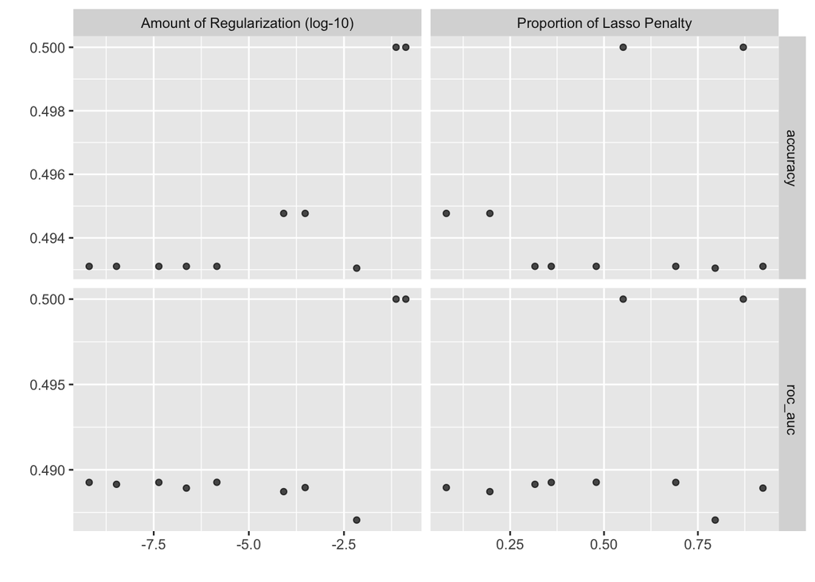

```r
# autoplot for logistic regression tuning results
autoplot(logistic_res)
```

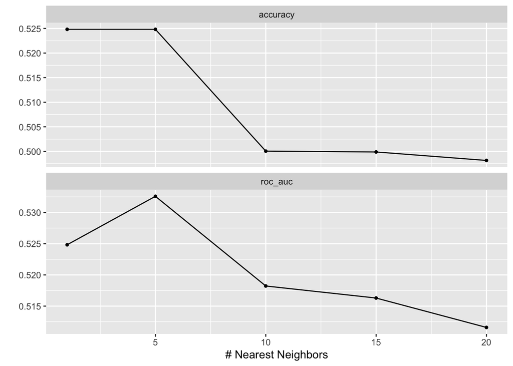

```r
# autoplot for knn tuning results
autoplot(knn_res)
```

Based on the auto plot of the KNN model, we can see that the most accurate neighbor is from about 3-5. We can also see that the ROC_AUC and accuracy are fairly coordinated to one another.

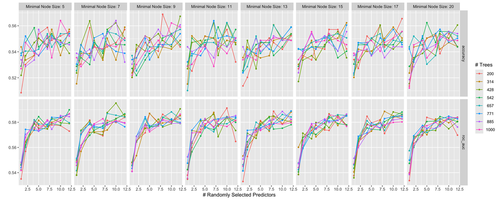

```r
# autoplot for random forest tuning results
autoplot(rf_res)
```

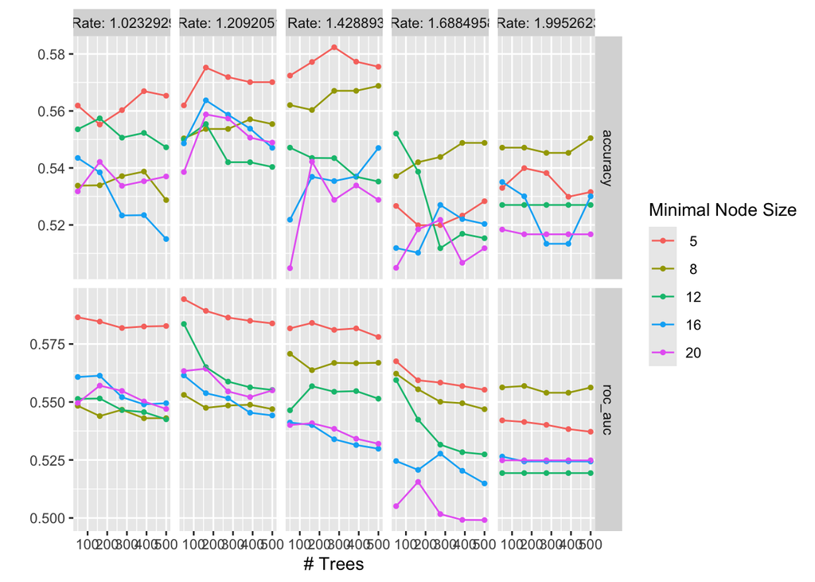

```r
# autoplot for boosted trees tuning results
autoplot(boosted_res)
```

Based on the autoplot we can see that node size 5 at rate 1.4288 has the highest accuracy.

```r
# Logistic Regression
logistic_metrics <- collect_metrics(logistic_res)


# KNN - Replace 'knn_results' with the actual results object for KNN
knn_metrics <- collect_metrics(knn_res)

# Random Forest - Replace 'rf_res' with the actual results object for Random Forest
rf_metrics <- collect_metrics(rf_res)

# Boosted Trees - Replace 'boosted_res' with the actual results object for Boosted Trees
boosted_metrics <- collect_metrics(boosted_res)

# SVM - Replace 'svm_res' with the actual results object for SVM
svm_metrics <- collect_metrics(svm_res)
```

```r
# Extract mean accuracy from metrics
extract_mean_accuracy <- function(metrics) {
  metrics %>%
    filter(.metric == "accuracy") %>%
    summarise(mean_accuracy = mean(mean, na.rm = TRUE), .groups = 'drop') %>%
    pull(mean_accuracy)
}

# Extract mean ROC AUC from metrics
extract_mean_roc_auc <- function(metrics) {
  metrics %>%
    filter(.metric == "roc_auc") %>%
    summarise(mean_roc_auc = mean(mean, na.rm = TRUE), .groups = 'drop') %>%
    pull(mean_roc_auc)
}


# Calculate accuracies and ROC AUCs
logistic_accuracy <- extract_mean_accuracy(logistic_metrics)
logistic_roc_auc <- extract_mean_roc_auc(logistic_metrics)

knn_accuracy <- extract_mean_accuracy(knn_metrics)
knn_roc_auc <- extract_mean_roc_auc(knn_metrics)

rf_accuracy <- extract_mean_accuracy(rf_metrics)
rf_roc_auc <- extract_mean_roc_auc(rf_metrics)

boosted_accuracy <- extract_mean_accuracy(boosted_metrics)
boosted_roc_auc <- extract_mean_roc_auc(boosted_metrics)

svm_accuracy <- extract_mean_accuracy(svm_metrics)
svm_roc_auc <- extract_mean_roc_auc(svm_metrics)

# Combine into one table
model_performance <- tibble(
  Model = c("Logistic Regression", "KNN", "Random Forest", "Boosted Trees", "SVM"),
  Accuracy = c(logistic_accuracy, knn_accuracy, rf_accuracy, boosted_accuracy, svm_accuracy),
  ROC_AUC = c(logistic_roc_auc, knn_roc_auc, rf_roc_auc, boosted_roc_auc, svm_roc_auc)
)

model_performance
```

```
## # A tibble: 5 × 3
##   Model               Accuracy ROC_AUC
##   <chr>                  <dbl>   <dbl>
## 1 Logistic Regression    0.495   0.491
## 2 KNN                    0.510   0.521
## 3 Random Forest          0.544   0.573
## 4 Boosted Trees          0.540   0.548
## 5 SVM                    0.466   0.511
```

# Testing the best models

```r
training_set <- training_set %>%
  select(-artist, -song_title)

testing_set <- testing_set %>%
  select(-artist, -song_title)


best_rf <- select_best(rf_res, metric = "roc_auc")

# Refit the Random Forest model with the best hyperparameters
final_rf_model <- rand_forest(trees = best_rf$trees, mtry = best_rf$mtry, min_n = best_rf$min_n) %>%
  set_engine("ranger") %>%
  set_mode("classification") %>%
  fit(opinion ~ ., data = training_set)

# Make predictions on the test set
rf_predictions <- predict(final_rf_model, testing_set) %>%
  bind_cols(testing_set)

rf_results <- rf_predictions %>%
  metrics(truth = opinion, estimate = .pred_class)

print(rf_results)
```

```
## # A tibble: 2 × 3
##   .metric  .estimator .estimate
##   <chr>    <chr>          <dbl>
## 1 accuracy binary         0.566
## 2 kap      binary         0.133
```

```r
best_boosted <- select_best(boosted_res, metric = "roc_auc")

# Refit the Boosted Trees model with the best hyperparameters
final_boosted_model <- boost_tree(trees = best_boosted$trees, min_n = best_boosted$min_n, learn_rate = best_boosted$learn_rate) %>%
  set_engine("xgboost") %>%
  set_mode("classification") %>%
  fit(opinion ~ ., data = training_set)

# Make predictions on the test set
boosted_predictions <- predict(final_boosted_model, testing_set) %>%
  bind_cols(testing_set)

boosted_results <- boosted_predictions %>%
  metrics(truth = opinion, estimate = .pred_class)

print(boosted_results)
```

```
## # A tibble: 2 × 3
##   .metric  .estimator .estimate
##   <chr>    <chr>          <dbl>
## 1 accuracy binary        0.523
## 2 kap      binary        0.0469
```

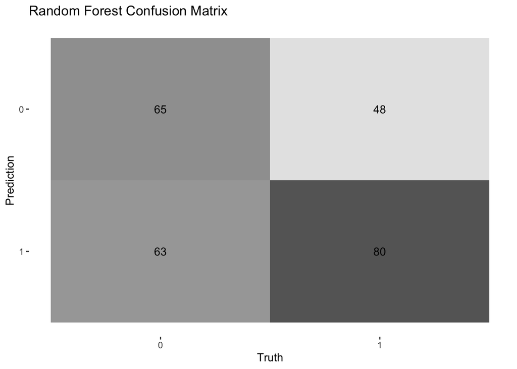

```r
# Confusion Matrix for Random Forest
rf_conf_mat <- rf_predictions %>%
  conf_mat(truth = opinion, estimate = .pred_class)

# Plot the confusion matrix for Random Forest
autoplot(rf_conf_mat, type = "heatmap") +
  labs(title = "Random Forest Confusion Matrix")
```

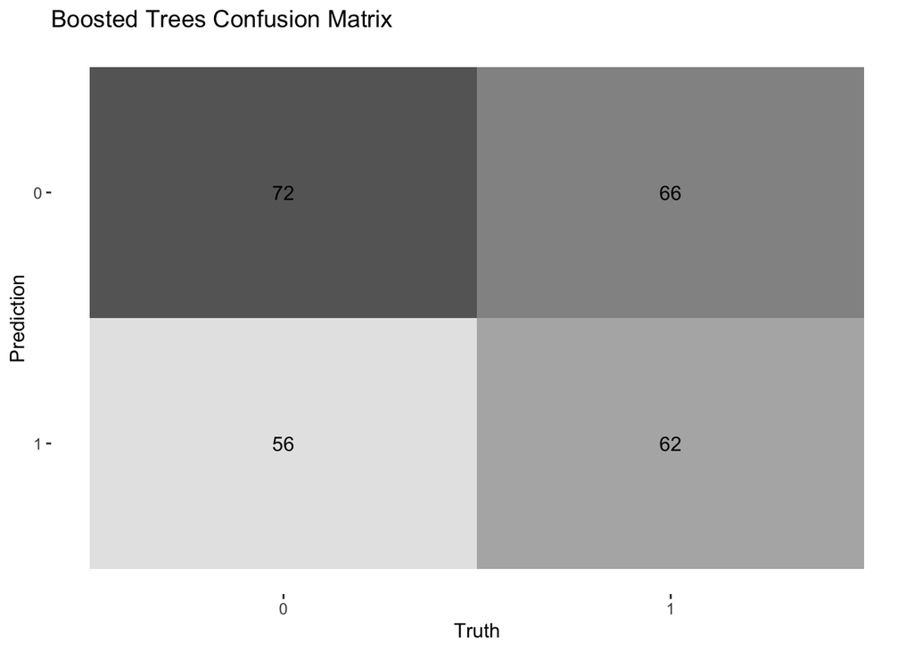

```r
# Confusion Matrix for Boosted Trees
boosted_conf_mat <- boosted_predictions %>%
  conf_mat(truth = opinion, estimate = .pred_class)

# Plot the confusion matrix for Boosted Trees
autoplot(boosted_conf_mat, type = "heatmap") +
  labs(title = "Boosted Trees Confusion Matrix")
```

# Conclusion

Based on my results Logistic regression and SV models seemed to perform the worst, and Random forest and boosted treees performed the best. However, the best was still had quite low accuracies and auc_roc.

Overall, I feel as though my results were underwhelming. Although not included, I did try making changes to my project to see if it would be possible to get better results from my model, but it was quite difficult to keep editing and running models on MacBook, as it would take 15-30 minutes to run them. I think there could possibly be issues with my recipe, or the variables from the songs of my playlist.

I do think that my dataset could have caused some issues considering that a lot of the songs were from the same or similar artists. This could have negatively impacted my models and could have caused some confusion on what I do and do not like. Looking back, when I created the playlist, I figured I would add whole albums, as I am a very picky music listener, and although I may love some songs from an albums, I also dislike songs from those same albums. Also, rather than handpicking each song to add, I used spotifys recommendations from when I would add a song to my playlist, and those recommendations are derived from similar songs as to the ones I hand picked. Reflecting on this I believe Spotifys song recommendations are derived from the songs attributes, so they give me sonsg with similar attributes as to the ones I like, and I did not necessarely like all those songs, but just added them as it was much easier than individually looking up every song. Taking this into consideration, if I have a playlist with not much variability when it comes to the songs’ attributes, but my opinion is different on those songs, I can see that it probably played a big role in my models’ low accuracy as I did not provide enough variety when it came to the songs’ attributes.

# Sources

The original dataset that I had found was from [Kaggle](https://www.kaggle.com/datasets/geomack/spotifyclassification?resource=download). I then used the [Spotify API](https://developer.spotify.com/documentation/web-api) to retrieve the attributes from the playlist I made myself.